# Species ID Guide Template

Payton Arthur

10/18/2021

# *Pagurus hirsutiusculus* (Hairy Hermit Crab)

## Description

Each organism can be black, brown or dark green (Meschkat et al., 2014). Shell shape can vary but shape of the actual body is fairly consistent with the shield of the carapace (most cranial part of the back of the crab) being less long than it is wide (Jensen, 2014). Body size can reach 2 cm (Meschkat et al., 2014). The hairy hermit crab has hairs along its body (Meschkat et al., 2014). However, the amount of hairs can vary from one individual to another (Jensen, 2014). On its walking legs, these crabs have a white band by the last joint (Meschkat et al., 2014). More white bands may be present if the individual is young (Jensen, 2014). Also, their walking legs often have at most two blue dots on each leg though these may be more difficult to see (Meschkat et al., 2014). Small light rings encircle their antennae (Meschkat et al., 2014).

**Species lookalike**  
It possesses one lookalike species: Pagurus carinus (the greenmark hermit crab) (Meschkat et al., 2014). However, this crab lacks rings on the antennae, possesses spiny claws and has a carapace that only reaches 1 cm which is half the size as hairy hermit crabs (Harbo, 2011).

**Range, Habitat, Diet, Foraging Mode and Reproduction**  
These crabs can be found between California (Monterey) and Alaska (Pribilof Islands) (Harbo, 2011). They live in protected areas including the intertidal zone in tidepools protected by algae (Meschkat et al., 2014; Harbo, 2011). Or, on the rare occasion, they may be found up to 110m subtidally (Harbo, 2011). These crabs are detrivores but will eat other live animals if available (Cowles, 2005b). They actively search for food by walking around (Jensen, 2014). They undergo sexual reproduction and are oviparous meaning they lay eggs (Kornienko, 2020).

## Questions

1. Are there hairs on the body?
2. Are there white bands around the last joints of the first two legs?
3. Are there rings circling around the antennae?

## Figures

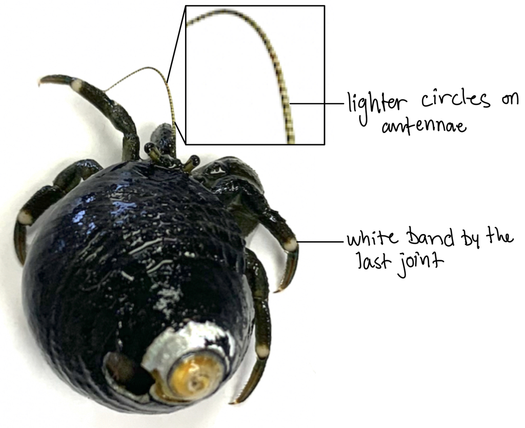

Figure 1. Photo of *Pagurus hirsutiusculus* including labeled diagnostic features

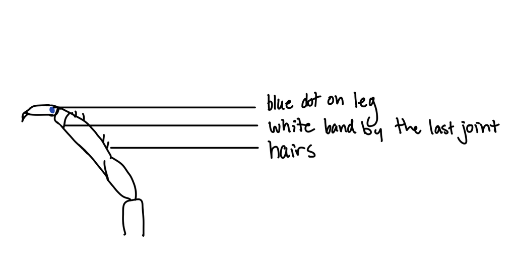

Figure 2. Drawing of the leg of *Pagurus hirsutiusculus* including labeled diagnostic features

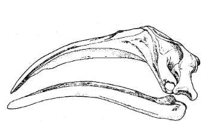

This is the skull of the southern right whale skull (lateral view), figure is left-aligned.

# *Balaena mysticetus* (Bowhead whale)

## Figures

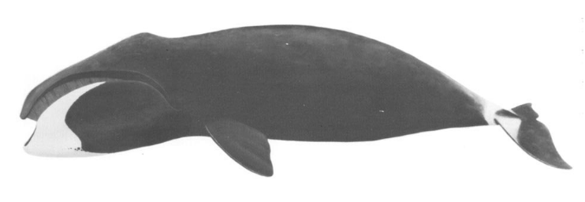

This is the bowhead whale, figure is centered.

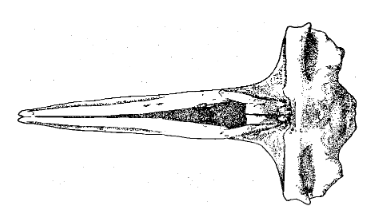

This is the skull of the bowhead whale skull, figure is centered.

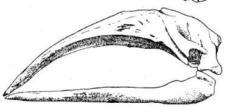

This is the skull of the bowhead whale skull, figure is centered.

# Supplemental Information

Whale morphometrics and other infomration.

| Species | Length | Weight | Trophic Role | Diet | Reproduction |
| --- | --- | --- | --- | --- | --- |
| Bowhead whale | 18..7-20.8 | 81542.79 - 90700 | predators | kril | sexual |
| Southern right whale | 14.5-18.2 | 63576.92 - 79800 | predators | krill | sexual |

# Supplemental Information

Table 1. Hermit crab morphometrics and other information.

| Individual | Shell Length (mm) | Claw Size (mm) |
| --- | --- | --- |
| Hairy Hermit Crab 1 | 7 | 2.5 |
| Hairy Hermit Crab 2 | 18 | 6.5 |
| Grainyhand Crab 1 | 19 | 4.0 |
| Grainyhand Crab 2 | 32 | 7.0 |

## Figures

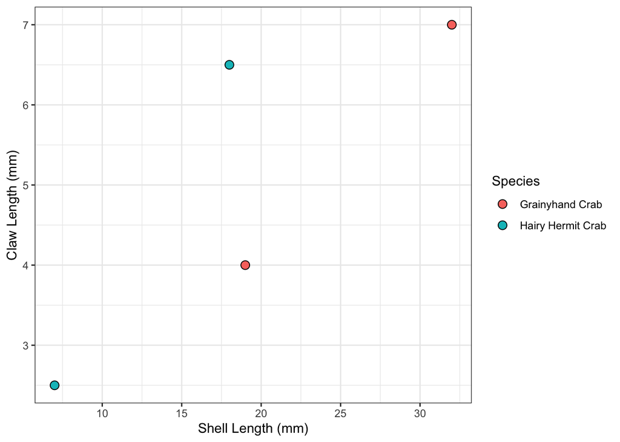

Figure 1. Shell lenght and claw length compared by species in hermit crabs.

## Figures

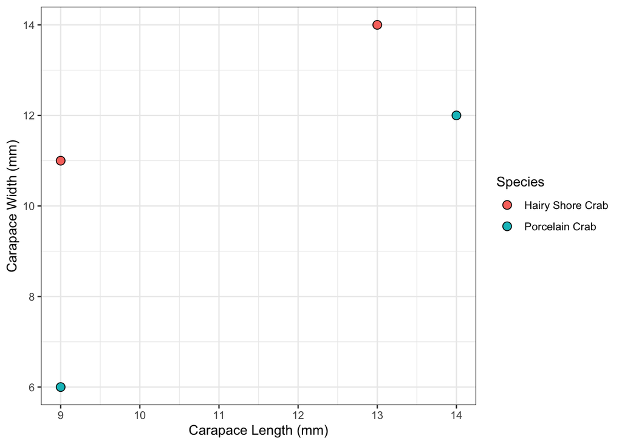

Carapce lenght and width compared by species of shore crabs.

## Figures

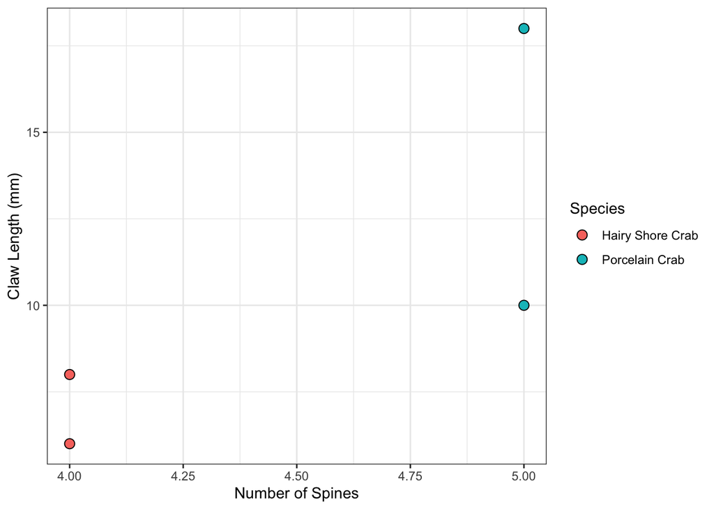

Number of spines and claw length compared by species of shore crabs.